# CS 329e Project 1 Steps

Monica Huang and Rachel Arthur

September 12, 2015

### **Step 1: Build a data frame for the Titanic data**

```r
source("../01 Data/SexNotNullDF.R", echo = TRUE)
```

```
##
## > df <- data.frame(fromJSON(getURL(URLencode("129.152.144.84:5001/rest/native/?query=\"select * from titanic where sex is not null\""),
## +     httphea .... [TRUNCATED]
```

### **Step 2: Display a subset and summary of the Titanic data frame**

```r
source("../01 Data/headAndSummary.R", echo = TRUE)
```

```
##
## > head(subset(df, select = c(PCLASS, NAME, FARE)))
##   PCLASS                                                NAME    FARE
## 1      3                             Braund, Mr. Owen Harris  7.2500
## 2      1 Cumings, Mrs. John Bradley (Florence Briggs Thayer) 71.2833
## 3      3                              Heikkinen, Miss. Laina  7.9250
## 4      1        Futrelle, Mrs. Jacques Heath (Lily May Peel) 53.1000
## 5      3                            Allen, Mr. William Henry  8.0500
## 6      3                                    Moran, Mr. James  8.4583
##
## > summary(df)
##   PASSENGERID       SURVIVED          PCLASS
##  Min.   :  1.0   Min.   :0.0000   Min.   :1.000
##  1st Qu.:222.8   1st Qu.:0.0000   1st Qu.:2.000
##  Median :445.5   Median :0.0000   Median :3.000
##  Mean   :445.6   Mean   :0.3834   Mean   :2.309
##  3rd Qu.:668.2   3rd Qu.:1.0000   3rd Qu.:3.000
##  Max.   :891.0   Max.   :1.0000   Max.   :3.000
##
##                                     NAME         SEX           AGE
##  Johansson, Mr. Gustaf Joel           :  2   female:314   null   :177
##  Abbing, Mr. Anthony                  :  1   male  :578   24     : 30
##  Abbott, Mr. Rossmore Edward          :  1                22     : 27
##  Abbott, Mrs. Stanton (Rosa Hunt)     :  1                18     : 26
##  Abelson, Mr. Samuel                  :  1                19     : 25
##  Abelson, Mrs. Samuel (Hannah Wizosky):  1                28     : 25
##  (Other)                              :885                (Other):582
##      SIBSP            PARCH             TICKET         FARE
##  Min.   :0.0000   Min.   :0.0000   1601    :  7   Min.   :  0.000
##  1st Qu.:0.0000   1st Qu.:0.0000   347082  :  7   1st Qu.:  7.918
##  Median :0.0000   Median :0.0000   CA. 2343:  7   Median : 14.454
##  Mean   :0.5224   Mean   :0.3812   3101295 :  6   Mean   : 32.178
##  3rd Qu.:1.0000   3rd Qu.:0.0000   347088  :  6   3rd Qu.: 31.000
##  Max.   :8.0000   Max.   :6.0000   CA 2144 :  6   Max.   :512.329
##                                    (Other) :853
##          CABIN     EMBARKED
##  null       :688   C   :168
##  B96 B98    :  4   null:  2
##  C23 C25 C27:  4   Q   : 77
##  G6         :  4   S   :645
##  C22 C26    :  3
##  D          :  3
##  (Other)    :186
```

### **Step 3: Produce one new, interesting plot for the Titanic data.**

Using the titanic dataframe produced in step 1 where sex is not null, this plot visualizes the age of passengers versus their fares and colored by sex. They are separated by passenger class. It demonstates that passengers in lower classes (2 and 3) all paid less than $100 for their fares despite their age or sex. In first class, many of the passengers paid over $100, as expected. However, it is interesting that there are more women that paid over $100 in first class than men. While men did pay the highest price out of all the ticket fares, a larger number of women had more expensive tickets, and were a younger age than men that paid a lower price for their first class tickets.

```
##
## > ggplot() + coord_cartesian() + scale_x_continuous() +
## +     scale_y_continuous() + facet_grid(PCLASS ~ ., labeller = label_both) +
## +     labs(titl .... [TRUNCATED]
```

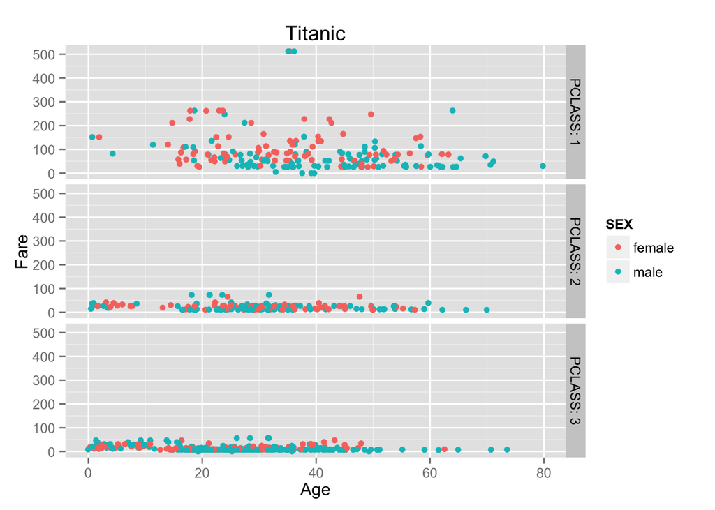

```r
 source("../02 Visualizations/UniquePlot.R", echo = TRUE)
```

### **Step 4: Produce the indicated plots**

#### Plot #1

For plot #1, the SQL statement selected all of the titanic data when creating the dataframe used in the visualization.

```r
source("../01 Data/AllTitanic.R", echo = TRUE)
```

```
##
## > df <- data.frame(fromJSON(getURL(URLencode("129.152.144.84:5001/rest/native/?query=\"select * from titanic\""),
## +     httpheader = c(DB = "jdbc:ora ..." ... [TRUNCATED]
```

```
##
## > ggplot() + coord_cartesian() + scale_x_continuous() +
## +     scale_y_continuous() + labs(title = "Titanic") + labs(x = "Age",
## +     y = "Fare") + l .... [TRUNCATED]
```

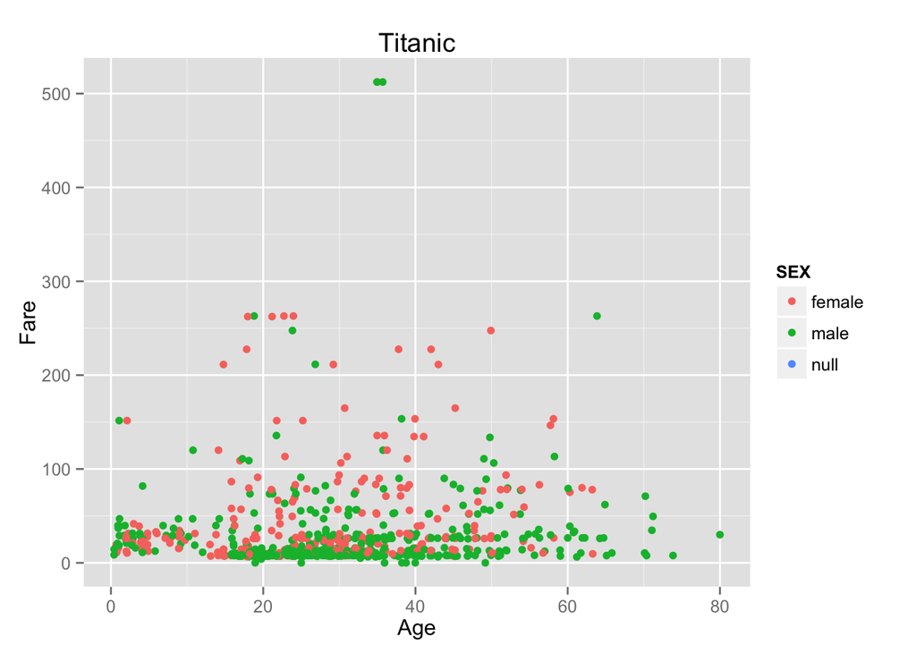

```r
source("../02 Visualizations/Plot1.R", echo = TRUE)
```

This plot uses a dataframe of the titanic data that includes all of the data. This plot visualizes the ages of all passengers versus their ticket fares. They are color coded by sex, and the legend includes a “null” category, because the query selector selected all of the data - even values equal to null. One observation is that a larger number of women paid fares over $200 than men.

#### The dataframe used in Plots #2-4 included only values where sex was not equal to null.

```r
source("../01 Data/SexNotNullDF.R", echo = TRUE)
```

```
##
## > df <- data.frame(fromJSON(getURL(URLencode("129.152.144.84:5001/rest/native/?query=\"select * from titanic where sex is not null\""),
## +     httphea .... [TRUNCATED]
```

#### Plot #2

```
##
## > ggplot() + coord_cartesian() + scale_x_continuous() +
## +     scale_y_continuous() + labs(title = "Titanic") + labs(x = "Age",
## +     y = "Fare") + l .... [TRUNCATED]
```

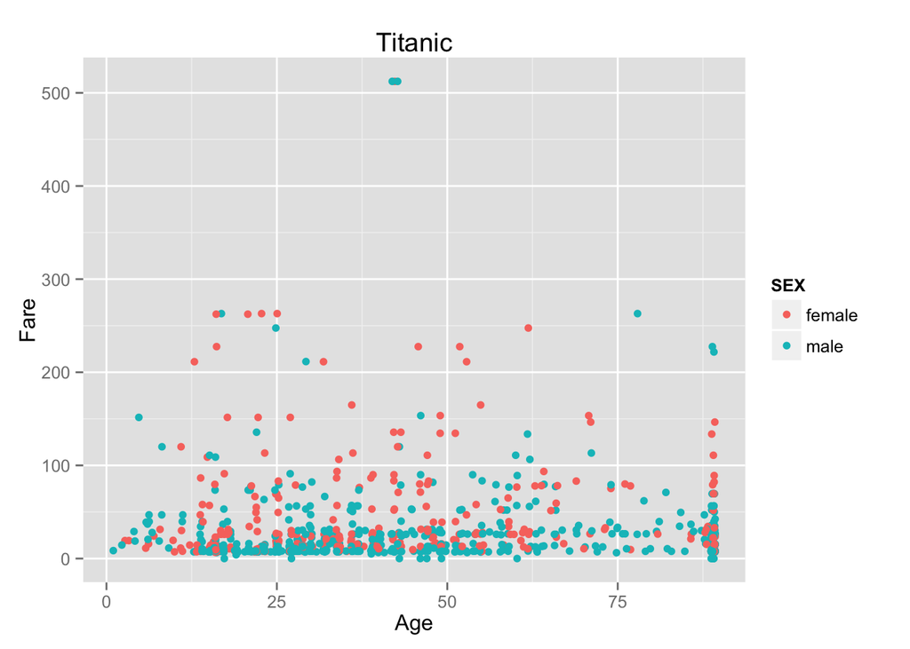

```r
source("../02 Visualizations/Plot2.R", echo = TRUE)
```

This plot visualizes the ages of all passengers versus their ticket fares. They are color coded by sex. A larger number of women paid fares over $200. It was created from a dataframe that used a query selector to select only values where sex was not equal to null.

#### Plot #3

```
##
## > ggplot() + coord_cartesian() + scale_x_discrete() +
## +     scale_y_continuous() + labs(title = "Titanic") + labs(x = "Survived",
## +     y = paste("F ..." ... [TRUNCATED]
```

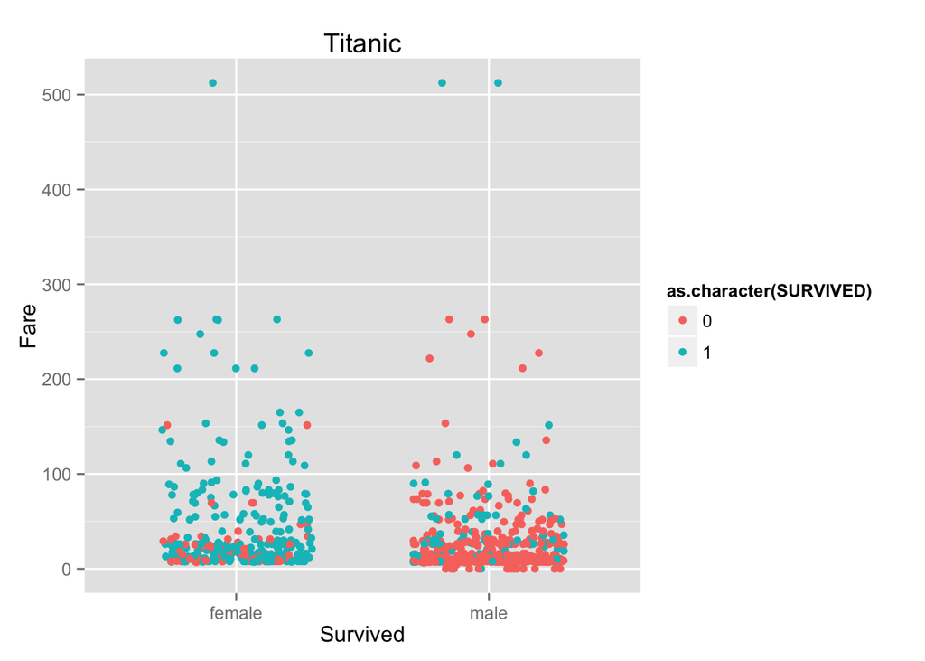

```r
source("../02 Visualizations/Plot3.R", echo = TRUE)
```

This plot visualizes the surviving males and females on the Titanic and their ticket fares. More women surivived the crash, which is not surprising because they were the ones allowed onto the life boats first, along with children. It was also made using the same dataframe as plot #2.

#### Plot #4

```
##
## > ggplot() + coord_cartesian() + scale_x_discrete() +
## +     scale_y_continuous() + facet_grid(PCLASS ~ SURVIVED, labeller = label_both) +
## +     labs .... [TRUNCATED]
```

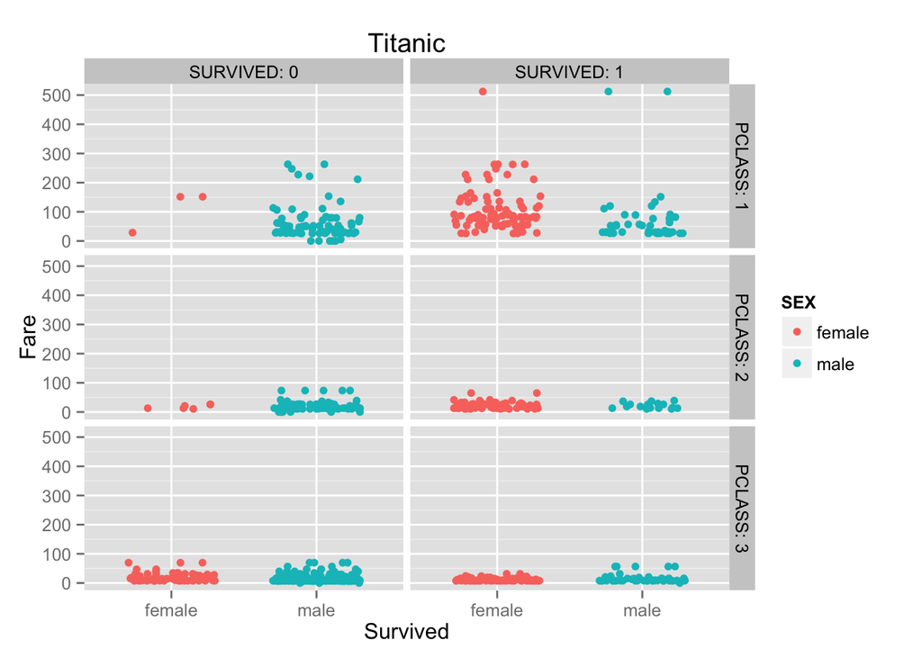

```r
source("../02 Visualizations/Plot4.R", echo = TRUE)
```

This plot shows whether passengers survived based on their ticket fare, sex, and class. Passengers in classes 1 and 2 were more likely to survive if they were females. Passengers in class 3 were less likely to survive than passengers in classes 1 and 2, whether they were male or female.

#### Plot #5

**The dataframe used in plot #5 selected only entries where AGE was less than or equal to 10**

```r
source("../01 Data/AgeLessThan10.R", echo = TRUE)
```

```
##
## > df <- data.frame(fromJSON(getURL(URLencode("129.152.144.84:5001/rest/native/?query=\"select * from titanic where age <= 10\""),
## +     httpheader =  .... [TRUNCATED]
```

```
##
## > ggplot() + coord_cartesian() + scale_x_discrete() +
## +     scale_y_continuous() + facet_grid(PCLASS ~ SURVIVED, labeller = label_both) +
## +     labs .... [TRUNCATED]
```

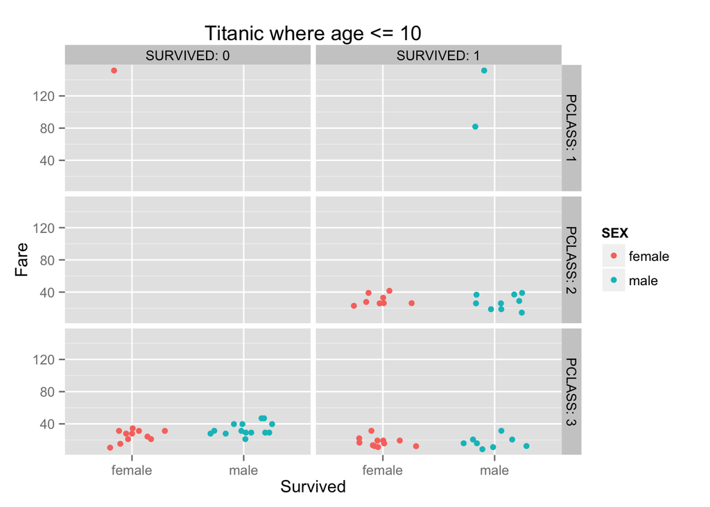

```r
source("../02 Visualizations/Plot5.R", echo = TRUE)
```

This plot shows the survival of passengers under the age of ten based on class, sex, and ticket fare. There is no clear difference between the survival of children in class 3, but class 2 children all survived. It was made using a query selector statement that selected only data where AGE was less than or equal to 10.